# Horse Colic Project

Destinee Morrow BIFX 551 Spring 2020

# Background:

Colic simply put means pain in the abdomen of the horse. There are various types of horse colic that include but are not limited to, impaction colic due to the type of feed and the eating process and gas colic that is built up over time, but can lead to more serve colic, like abdomen dystension and colon shift. All of these, can potentially lead to death if the horse if not treated. Horse colic is very common and understanding the severity and needed procedures is important.

Link to website where this information can be found is [here](https://extension.umn.edu/horse-health/colic-your-horse#types-of-colic--71561).

# Data:

The data I used to explore horse colic can be found at the link below.

Accessed from [kaggle](https://www.kaggle.com/uciml/horse-colic/download) on Feb 25 2020 @ 6:28pm. All column meanings in the data frame have been explicited stated.

```r
library(dplyr)
```

```r
library(ggplot2)
library(tidyverse)
#setwd("/Users/destinee/Documents/Programming")
horsecolic <- read.csv("horse.csv")
```

```r
head(horsecolic)
```

```
##   surgery   age hospital_number rectal_temp pulse respiratory_rate
## 1      no adult          530101        38.5    66               28
## 2     yes adult          534817        39.2    88               20
## 3      no adult          530334        38.3    40               24
## 4     yes young         5290409        39.1   164               84
## 5      no adult          530255        37.3   104               35
## 6      no adult          528355          NA    NA               NA
##   temp_of_extremities peripheral_pulse mucous_membrane capillary_refill_time
## 1                cool          reduced            <NA>            more_3_sec
## 2                <NA>             <NA>   pale_cyanotic            less_3_sec
## 3              normal           normal       pale_pink            less_3_sec
## 4                cold           normal   dark_cyanotic            more_3_sec
## 5                <NA>             <NA>   dark_cyanotic            more_3_sec
## 6                warm           normal       pale_pink            less_3_sec
##           pain peristalsis abdominal_distention nasogastric_tube
```

[output cut: 27 more lines]

```r
summary(horsecolic)
```

```
##    surgery              age            hospital_number    rectal_temp
##  Length:299         Length:299         Min.   : 518476   Min.   :35.40
##  Class :character   Class :character   1st Qu.: 528904   1st Qu.:37.80
##  Mode  :character   Mode  :character   Median : 530301   Median :38.20
##                                        Mean   :1087733   Mean   :38.17
##                                        3rd Qu.: 534736   3rd Qu.:38.50
##                                        Max.   :5305629   Max.   :40.80
##                                                          NA's   :60
##      pulse     respiratory_rate temp_of_extremities peripheral_pulse
##  Min.   : 30   Min.   : 8.00    Length:299          Length:299
##  1st Qu.: 48   1st Qu.:18.00    Class :character    Class :character
##  Median : 64   Median :25.00    Mode  :character    Mode  :character
##  Mean   : 72   Mean   :30.46
##  3rd Qu.: 88   3rd Qu.:36.00
##  Max.   :184   Max.   :96.00
##  NA's   :24    NA's   :58
##  mucous_membrane    capillary_refill_time     pain           peristalsis
##  Length:299         Length:299            Length:299         Length:299
##  Class :character   Class :character      Class :character   Class :character
##  Mode  :character   Mode  :character      Mode  :character   Mode  :character
##
##
##
##
##  abdominal_distention nasogastric_tube   nasogastric_reflux
##  Length:299           Length:299         Length:299
##  Class :character     Class :character   Class :character
##  Mode  :character     Mode  :character   Mode  :character
##
##
##
##
##  nasogastric_reflux_ph rectal_exam_feces    abdomen          packed_cell_volume
##  Min.   :1.000         Length:299         Length:299         Min.   :23.00
##  1st Qu.:3.000         Class :character   Class :character   1st Qu.:38.00
##  Median :5.000         Mode  :character   Mode  :character   Median :45.00
##  Mean   :4.708                                               Mean   :46.31
##  3rd Qu.:6.500                                               3rd Qu.:52.00
##  Max.   :7.500                                               Max.   :75.00
##  NA's   :246                                                 NA's   :29
```

[output cut: 9 more lines]

```
##  Length:299         Min.   :    0   Min.   :   0.00   Min.   :   0.000
##  Class :character   1st Qu.: 2112   1st Qu.:   0.00   1st Qu.:   0.000
##  Mode  :character   Median : 2322   Median :   0.00   Median :   0.000
##                     Mean   : 3660   Mean   :  90.53   Mean   :   7.388
##                     3rd Qu.: 3209   3rd Qu.:   0.00   3rd Qu.:   0.000
##                     Max.   :41110   Max.   :7111.00   Max.   :2209.000
##
##    cp_data
##  Length:299
##  Class :character
##  Mode  :character
##
##
##
##
```

# Exploritory Analysis

Lets begin by looking at some sample graphs to get a feel for the data set.

### Temperature

Below is a bar chart showing the mean rectal temperatures of horses in comparison to the temperature of the of extremities to the touch.

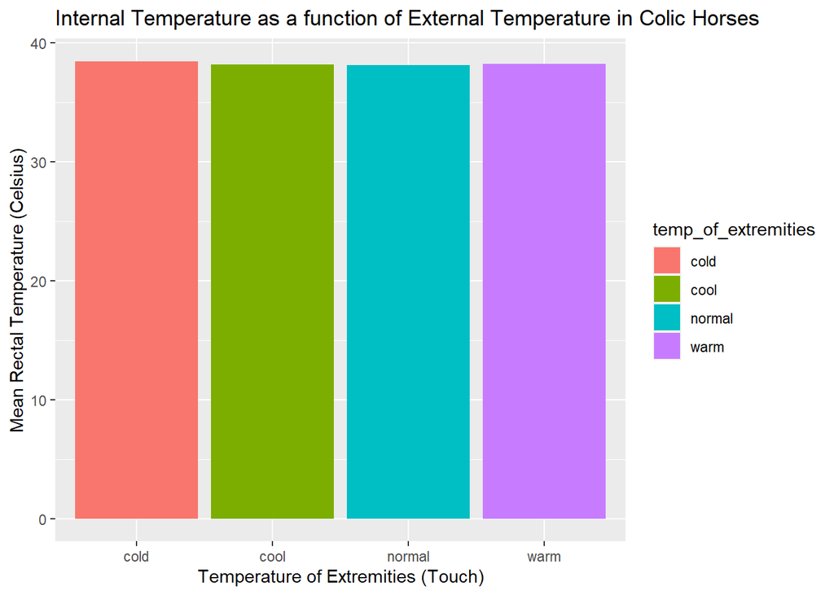

```r
temp <- horsecolic %>% group_by(temp_of_extremities) %>% drop_na(temp_of_extremities) %>% summarize(mean = mean(rectal_temp, na.rm = TRUE))
temp <- as.data.frame(temp)
ggplot(temp, aes(temp_of_extremities,mean)) +geom_col(aes(fill=temp_of_extremities)) + xlab("Temperature of Extremities (Touch)") + ylab("Mean Rectal Temperature (Celsius)") + ggtitle("Internal Temperature as a function of External Temperature in Colic Horses")
```

As you can see, there is barely any difference in the internal temperatures. Thus meaning, one should not rely on just feeling the outside of the horse to determine temperature or potential severity of colic.

### Pulse and Respitory Rate

Is there a correlation between the respitory rate and the pulse?

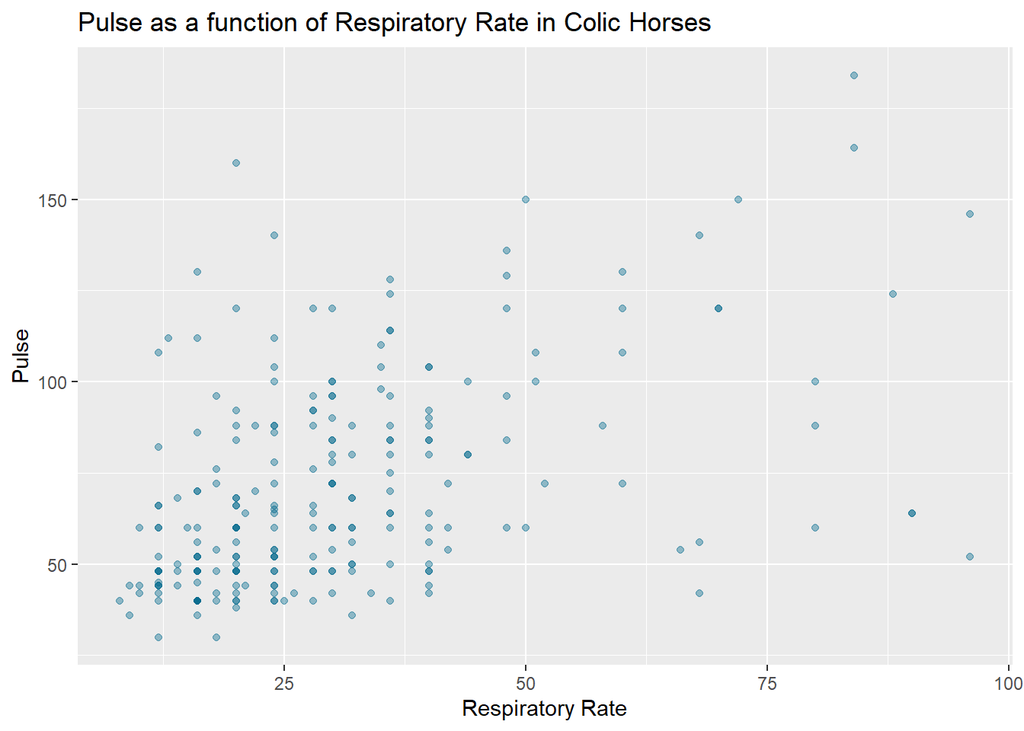

```r
ggplot(horsecolic %>% drop_na(c(respiratory_rate, pulse)), aes(respiratory_rate, pulse)) +geom_point(alpha=0.4, color="deepskyblue4") + xlab("Respiratory Rate") + ylab("Pulse") + ggtitle("Pulse as a function of Respiratory Rate in Colic Horses")
```

Additionally, various outliers can be seen where a horse had a lower RR and very high pulse, or vice versa, meaning that respitory rate would not be effective at predicting pulse.

# Hypothesis:

My hypothesis for this data has two separate aims. The first aim is that PCV can tell us whether or not the horse needs to have surgery. The second aim is that surgery has the desired outcome of “fixing” the colic and allowing the horse to survive.

### Packed Cell Volume

This first graph below looks at packed cell volume. This is a quick blood test that could be used to then give further assesment of the horse.

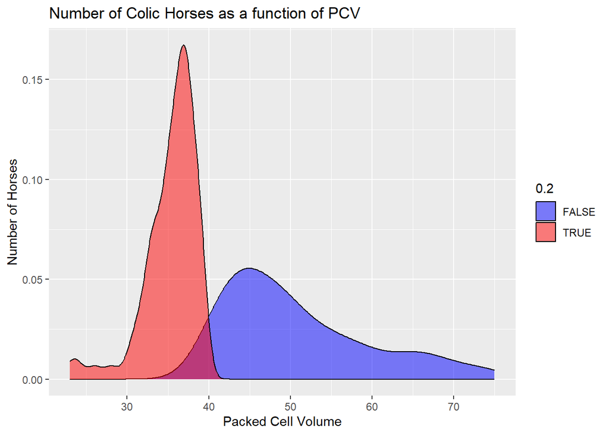

```r
ggplot(horsecolic %>% drop_na(packed_cell_volume), aes(packed_cell_volume)) + geom_density( aes(fill = packed_cell_volume < 40), alpha=0.5) + scale_fill_manual(values = c("blue","red"), 0.2) + xlab("Packed Cell Volume") +ylab("Number of Horses") +ggtitle("Number of Colic Horses as a function of PCV")
```

It appears that more than half of the sample size has a healthy PCV count, which is normally 33% to 50%. This to me, initially says it would not be a good indicater of the severity of colic in horses.

However, further exploration using a t-test can tell us whether or not PCV is correlated to the horse having surgery.

##### T-Test

```r
t.test(horsecolic$packed_cell_volume ~ horsecolic$surgery)
```

```
##
##  Welch Two Sample t-test
##
## data:  horsecolic$packed_cell_volume by horsecolic$surgery
## t = -0.69123, df = 234.85, p-value = 0.4901
## alternative hypothesis: true difference in means between group no and group yes is not equal to 0
## 95 percent confidence interval:
##  -3.436181  1.651235
## sample estimates:
##  mean in group no mean in group yes
##          45.77523          46.66770
```

With a p value 0.4901, we fail to reject the null hypothesis, that PCV is the same for both horses that received surgery and those that did not. The 95% confidence interval says that there is a 95% chance that the mean will fall between -3.4361 and 1.6512 Thus meaning, that my original hypothesis was incorrect and PCV is not a good indicator, and should not determine whether or not the horse will have to go through surgery.

So… If PCV cant tell us whether or not the horse will have to have surgery. The question is… Should the horse ultimately have surgery or not?

### Surgery?

The final two graphs are used to compare whether or not the horse received surgery for the colic and then how many of those horses ended up surviving.

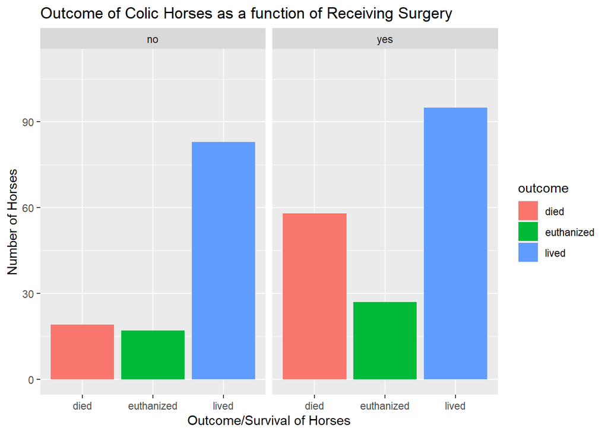

```r
horsecolic[horsecolic$outcome=='euthanized', "outcome2"] <- "died"
horsecolic[horsecolic$outcome=='lived', "outcome2"] <- "lived"
horsecolic[horsecolic$outcome=='died', "outcome2"] <- "died"
hoc <- horsecolic %>% group_by(surgery) %>% count(outcome)
hoc <- as.data.frame(hoc)
ggplot(hoc, aes(outcome, n)) + geom_col(aes(fill=outcome)) +ylim(0,110) + facet_grid(. ~ surgery) +xlab("Outcome/Survival of Horses") + ylab("Number of Horses") + ggtitle("Outcome of Colic Horses as a function of Receiving Surgery")
```

This graph is very intuative, in that, there is almost an even number of horses that lived on after having colic whether or not they had surgery. However, more horses died or had to be euthanized after they received surgery for the colic. This to me says that horses should receive supplemental medicine and care to help releave the distress instead of surgery. In order to confidently say this, below, a chi-squared test is used.

Now lets look at a graph where we combine both horses that died during sugery and horses that had to be euthanized.

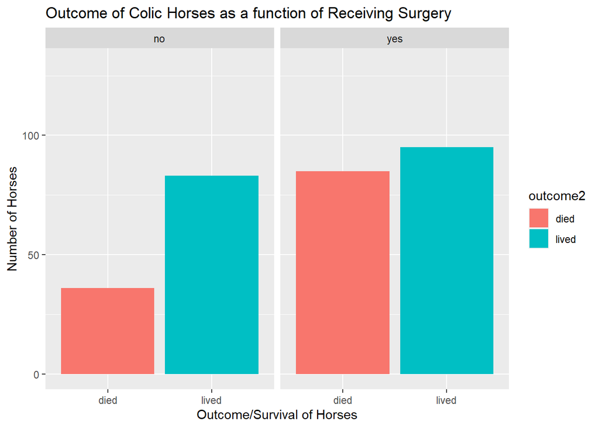

```r
hoc <- horsecolic %>% group_by(surgery) %>% count(outcome2)
hoc <- as.data.frame(hoc)
ggplot(hoc, aes(outcome2, n), na.rm=TRUE) + geom_col(aes(fill=outcome2)) +ylim(0,130) + facet_grid(. ~ surgery) +xlab("Outcome/Survival of Horses") + ylab("Number of Horses") + ggtitle("Outcome of Colic Horses as a function of Receiving Surgery")
```

This graph shows us that the number of horses who underwent surgery, was almost the same for dying vs. living. Additionally, the number of horses that lived was nearly the same for both groups.

So should we have a horse undergo surgery to fix the colic? We will use a Chi-squared Test to determine that answer.

##### Chi-Squared

First, this test looks at two random variables. x and y are called independent if the probability distribution of one variable is not affected by the presence of another. This test allows me to look at the dependences of two variables that are categorical.

```r
tbl <- table(horsecolic$surgery, horsecolic$outcome)
tbl
```

```
##
##       died euthanized lived
##   no    19         17    83
##   yes   58         27    95
```

```r
chisq.test(tbl)
```

```
##
##  Pearson's Chi-squared test
##
## data:  tbl
## X-squared = 10.841, df = 2, p-value = 0.004424
```

```r
tbl2 <- table(horsecolic$surgery, horsecolic$outcome2)
tbl2
```

```
##
##       died lived
##   no    36    83
##   yes   85    95
```

```r
chisq.test(tbl2)
```

```
##
##  Pearson's Chi-squared test with Yates' continuity correction
##
## data:  tbl2
## X-squared = 7.8737, df = 1, p-value = 0.005016
```

## Conclusion:

The Chi-Squared tests are based on a null hypothesis of surgery and survival being independent. The p values of 0.004424 and 0.005016 are significantly smaller than that of the 0.05 alpha. Thus meaning, that we reject the null hypothesis that whether a horse has surgery or not is independent of whether the horse survives from colic.